# Assignment 4 - Cluster Analysis

Hiba Bashir

2026-06-21

# Cluster Analysis of Pharmaceutical Firms

## Load the Data

```r
pharma <- read.csv(file.choose())

head(pharma)
```

```
##   Symbol                Name Market_Cap Beta PE_Ratio  ROE  ROA Asset_Turnover
## 1    ABT Abbott Laboratories      68.44 0.32     24.7 26.4 11.8            0.7
## 2    AGN      Allergan, Inc.       7.58 0.41     82.5 12.9  5.5            0.9
## 3    AHM        Amersham plc       6.30 0.46     20.7 14.9  7.8            0.9
## 4    AZN     AstraZeneca PLC      67.63 0.52     21.5 27.4 15.4            0.9
## 5    AVE             Aventis      47.16 0.32     20.1 21.8  7.5            0.6
## 6    BAY            Bayer AG      16.90 1.11     27.9  3.9  1.4            0.6
##   Leverage Rev_Growth Net_Profit_Margin Median_Recommendation Location Exchange
## 1     0.42       7.54              16.1          Moderate Buy       US     NYSE
## 2     0.60       9.16               5.5          Moderate Buy   CANADA     NYSE
## 3     0.27       7.05              11.2            Strong Buy       UK     NYSE
## 4     0.00      15.00              18.0         Moderate Sell       UK     NYSE
## 5     0.34      26.81              12.9          Moderate Buy   FRANCE     NYSE
## 6     0.00      -3.17               2.6                  Hold  GERMANY     NYSE
```

```r
str(pharma)
```

```
## 'data.frame':    21 obs. of  14 variables:
##  $ Symbol               : chr  "ABT" "AGN" "AHM" "AZN" ...
##  $ Name                 : chr  "Abbott Laboratories" "Allergan, Inc." "Amersham plc" "AstraZeneca PLC" ...
##  $ Market_Cap           : num  68.44 7.58 6.3 67.63 47.16 ...
##  $ Beta                 : num  0.32 0.41 0.46 0.52 0.32 1.11 0.5 0.85 1.08 0.18 ...
##  $ PE_Ratio             : num  24.7 82.5 20.7 21.5 20.1 27.9 13.9 26 3.6 27.9 ...
##  $ ROE                  : num  26.4 12.9 14.9 27.4 21.8 3.9 34.8 24.1 15.1 31 ...
##  $ ROA                  : num  11.8 5.5 7.8 15.4 7.5 1.4 15.1 4.3 5.1 13.5 ...
##  $ Asset_Turnover       : num  0.7 0.9 0.9 0.9 0.6 0.6 0.9 0.6 0.3 0.6 ...
##  $ Leverage             : num  0.42 0.6 0.27 0 0.34 0 0.57 3.51 1.07 0.53 ...
##  $ Rev_Growth           : num  7.54 9.16 7.05 15 26.81 ...
##  $ Net_Profit_Margin    : num  16.1 5.5 11.2 18 12.9 2.6 20.6 7.5 13.3 23.4 ...
##  $ Median_Recommendation: chr  "Moderate Buy" "Moderate Buy" "Strong Buy" "Moderate Sell" ...
##  $ Location             : chr  "US" "CANADA" "UK" "UK" ...
##  $ Exchange             : chr  "NYSE" "NYSE" "NYSE" "NYSE" ...
```

## a. Cluster the firms using numerical variables (1–9)

```r
pharma.num <- pharma[,3:11]

head(pharma.num)
```

```
##   Market_Cap Beta PE_Ratio  ROE  ROA Asset_Turnover Leverage Rev_Growth
## 1      68.44 0.32     24.7 26.4 11.8            0.7     0.42       7.54
## 2       7.58 0.41     82.5 12.9  5.5            0.9     0.60       9.16
## 3       6.30 0.46     20.7 14.9  7.8            0.9     0.27       7.05
## 4      67.63 0.52     21.5 27.4 15.4            0.9     0.00      15.00
## 5      47.16 0.32     20.1 21.8  7.5            0.6     0.34      26.81
## 6      16.90 1.11     27.9  3.9  1.4            0.6     0.00      -3.17
##   Net_Profit_Margin
## 1              16.1
## 2               5.5
## 3              11.2
## 4              18.0
## 5              12.9
## 6               2.6
```

```r
pharma.scaled <- scale(pharma.num)

head(pharma.scaled)
```

```
##      Market_Cap        Beta    PE_Ratio         ROE        ROA Asset_Turnover
## [1,]  0.1840960 -0.80125356 -0.04671323  0.04009035  0.2416121      0.0000000
## [2,] -0.8544181 -0.45070513  3.49706911 -0.85483986 -0.9422871      0.9225312
## [3,] -0.8762600 -0.25595600 -0.29195768 -0.72225761 -0.5100700      0.9225312
## [4,]  0.1702742 -0.02225704 -0.24290879  0.10638147  0.9181259      0.9225312
## [5,] -0.1790256 -0.80125356 -0.32874435 -0.26484883 -0.5664461     -0.4612656
## [6,] -0.6953818  2.27578267  0.14948233 -1.45146000 -1.7127612     -0.4612656
##        Leverage Rev_Growth Net_Profit_Margin
## [1,] -0.2120979 -0.5277675        0.06168225
## [2,]  0.0182843 -0.3811391       -1.55366706
## [3,] -0.4040831 -0.5721181       -0.68503583
## [4,] -0.7496565  0.1474473        0.35122600
## [5,] -0.3144900  1.2163867       -0.42597037
## [6,] -0.7496565 -1.4971443       -1.99560225
```

The data were standardized because the variables are measured on different scales. This ensures that each variable contributes equally to the clustering analysis.

```r
library(factoextra)
```

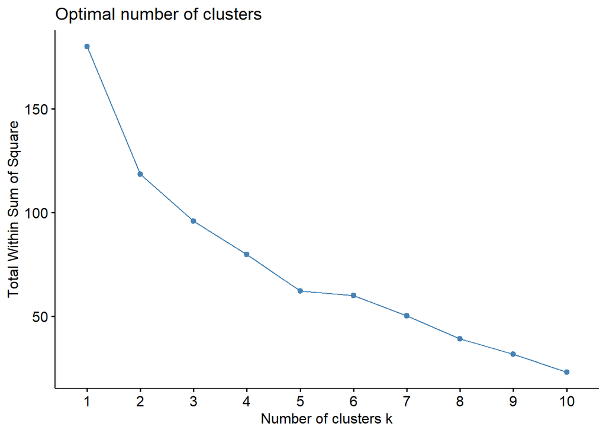

```r
fviz_nbclust(pharma.scaled, kmeans, method = "wss")
```

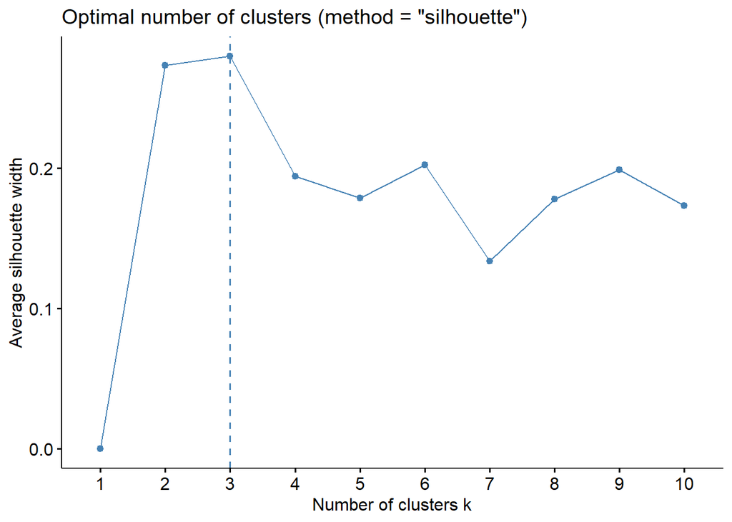

```r
fviz_nbclust(pharma.scaled, kmeans, method = "silhouette")
```

```r
set.seed(123)

km.pharma <- kmeans(pharma.scaled,
                    centers = 4,
                    nstart = 25)

km.pharma
```

```
## K-means clustering with 4 clusters of sizes 4, 8, 6, 3
##
## Cluster means:
##    Market_Cap       Beta   PE_Ratio        ROE        ROA Asset_Turnover
## 1  1.69558112 -0.1780563 -0.1984582  1.2349879  1.3503431   1.153164e+00
## 2 -0.03142211 -0.4360989 -0.3172485  0.1950459  0.4083915   1.729746e-01
## 3 -0.82617719  0.4775991 -0.3696184 -0.5631589 -0.8514589  -9.994088e-01
## 4 -0.52462814  0.4451409  1.8498439 -1.0404550 -1.1865838   1.480297e-16
##     Leverage Rev_Growth Net_Profit_Margin
## 1 -0.4680782  0.4671788         0.5912425
## 2 -0.2744931 -0.7041516         0.5569544
## 3  0.8502201  0.9158889        -0.3319956
## 4 -0.3443544 -0.5769454        -1.6095439
##
## Clustering vector:
##  [1] 2 4 2 2 3 4 2 3 3 2 1 3 1 3 1 2 1 4 2 3 2
##
## Within cluster sum of squares by cluster:
## [1]  9.284424 21.879320 32.143356 14.938904
##  (between_SS / total_SS =  56.5 %)
##
## Available components:
##
## [1] "cluster"      "centers"      "totss"        "withinss"     "tot.withinss"
## [6] "betweenss"    "size"         "iter"         "ifault"
```

The k-means algorithm was used because it is a non-hierarchical clustering method that groups similar observations. The variables were given equal weight after standardization. Based on the Elbow Method, four clusters were selected.

## b. Interpret the clusters

```r
pharma$Cluster <- as.factor(km.pharma$cluster)

aggregate(pharma.num,
          by=list(Cluster=pharma$Cluster),
          mean)
```

```
##   Cluster Market_Cap      Beta PE_Ratio     ROE       ROA Asset_Turnover
## 1       1  157.01750 0.4800000 22.22500 44.4250 17.700000      0.9500000
## 2       2   55.81000 0.4137500 20.28750 28.7375 12.687500      0.7375000
## 3       3    9.23500 0.6483333 19.43333 17.3000  5.983333      0.4833333
## 4       4   26.90667 0.6400000 55.63333 10.1000  4.200000      0.7000000
##    Leverage Rev_Growth Net_Profit_Margin
## 1 0.2200000  18.532500         19.575000
## 2 0.3712500   5.591250         19.350000
## 3 1.2500000  23.490000         13.516667
## 4 0.3166667   6.996667          5.133333
```

Cluster 1 contains large pharmaceutical companies with high profitability and strong financial performance.

Cluster 2 contains stable companies with moderate financial performance and lower market risk.

Cluster 3 contains smaller firms with higher leverage and stronger revenue growth.

Cluster 4 contains firms with high P/E ratios but weaker profitability.

## c. Patterns in variables 10–12

```r
table(pharma$Cluster, pharma$Median_Recommendation)
```

```
##
##     Hold Moderate Buy Moderate Sell Strong Buy
##   1    2            2             0          0
##   2    4            1             2          1
##   3    1            3             2          0
##   4    2            1             0          0
```

```r
table(pharma$Cluster, pharma$Location)
```

```
##
##     CANADA FRANCE GERMANY IRELAND SWITZERLAND UK US
##   1      0      0       0       0           0  1  3
##   2      0      0       0       0           1  2  5
##   3      0      1       0       1           0  0  4
##   4      1      0       1       0           0  0  1
```

```r
table(pharma$Cluster, pharma$Exchange)
```

```
##
##     AMEX NASDAQ NYSE
##   1    0      0    4
##   2    0      0    8
##   3    1      1    4
##   4    0      0    3
```

The recommendations are mixed across clusters, indicating no strong relationship between analyst recommendations and cluster membership.

Most companies are headquartered in the United States, while the remaining firms are spread across several countries. Therefore, location does not strongly influence the clusters.

Most firms are listed on the NYSE regardless of cluster membership. Only one company is listed on NASDAQ and one on AMEX, suggesting that stock exchange is not a major factor in the clustering.

## d. Name each cluster

- Cluster 1: Large High-Performance Firms
- Cluster 2: Stable Established Firms
- Cluster 3: High-Growth Higher-Risk Firms
- Cluster 4: Low-Performance High P/E Firms

## Conclusion

K-means clustering grouped the 21 pharmaceutical firms into four distinct clusters based on nine financial variables. Standardizing the data ensured that all variables contributed equally. The results indicate that pharmaceutical companies differ primarily in market capitalization, profitability, leverage, growth, and financial performance.